# Loan Approval Prediction

## Presented By:

### Georges Moussa: 62230250

## CSCI441 - Machine Learning

## Supervised by: Mr. Maher Abdul Rahman

# Table of Contents:

# 1. Introduction

### 1.1 Dataset Description

### 1.2 Project Objective

# 2. The DataSet

### 2.1 Required Packages

### 2.2 Data Overview

### 2.3 Data Understanding

# 3. Data Exploration

### 3.1 Box Plots for Numerical Columns

### 3.2 KDE Plots for Numerical Columns

### 3.3 Bar Plots for Categorical Columns

### 3.4 Target Distribution Analysis

### 3.5 Correlation Analysis

3.5.1 Encoding Categorical Columns  
3.5.2 Correlation Matrix  
3.5.3 Correlation with Target Column

# 4. Data Preprocessing

### 4.1 Standardization

### 4.2 Discretization

# 5. Data Modeling

### 5.1 Decision Tree Classifier

### 5.2 Random Forest Classifier

### 5.3 Gaussian Naive Bayes

### 5.4 Multinomial Naive Bayes

### 5.5 KNearest Neighbors Classifier (KNN)

# 6. Model Evaluation

### 6.1 Model Comparison Based on Accuracy

### 6.2 Model Comparison Based on Precision

### 6.3 Model Comparison Based on Recall

### 6.4 Model Comparison Based on F1 Score

### 6.5 Table of Metrics

# 7. Conclusion

# 1. Introduction

### 1.1 Dataset Description

This dataset (**3,218 KB**) was obtained from **Kaggle**, a popular platform for data science competitions and datasets. You can access the dataset using the following link:  
[Dataset Link on Kaggle](https://www.kaggle.com/datasets/taweilo/loan-approval-classification-data)

> 1. **person_age**: Age of the loan applicant.
> 2. **person_gender**: Gender of the applicant (male/female).
> 3. **person_education**: Highest education level (e.g., High School, Bachelor, Master).
> 4. **person_income**: Yearly income of the applicant in US dollars.
> 5. **person_emp_exp**: Employment experience in years.
> 6. **person_home_ownership**: Housing status (e.g., Rent, Own, Mortgage).
> 7. **loan_amnt**: Amount of the loan requested in US Dollars.
> 8. **loan_intent**: Purpose of the loan (e.g., Medical, Education, Personal).
> 9. **loan_int_rate**: Interest rate of the loan.
> 10. **loan_percent_income**: Percentage of income allocated to the loan.
> 11. **cb_person_cred_hist_length**: Length of the applicant's credit history (in years).
> 12. **credit_score**: Credit score of the applicant.
> 13. **previous_loan_defaults_on_file**: Indicates if the applicant has defaulted on previous loans (Yes/No).

### Project Objective

> The loan approval process is a critical aspect of financial institutions, directly impacting profitability and risk management. This project aims to analyze and visualize patterns and trends in loan approval decisions.

> The primary objective is to identify the factors influencing loan approvals and uncover meaningful insights through data visualization. By analyzing the dataset, this project seeks to understand the profiles of individuals most likely to have their loans approved.

# 2. The Dataset

### 2.1 Required Packages

> 1. **math**: A Python module providing mathematical functions like exponentials, logarithms, trigonometric operations, and more.
> 2. **pandas**: A powerful library for data manipulation and analysis, offering data structures like DataFrames for handling structured data efficiently.
> 3. **matplotlib.pyplot**: A module for creating static, interactive, and animated visualizations in Python, commonly used for 2D plots.
> 4. **matplotlib.cm**: A submodule of Matplotlib that provides colormaps for visualizations, enabling effective representation of data distributions.
> 5. **seaborn**: A statistical data visualization library built on Matplotlib, offering easy-to-use functions for creating attractive and informative plots.
> 6. **datetime**: A Python module for handling date and time data, useful for tracking execution times and working with temporal data.
> 7. **LabelEncoder (sklearn.preprocessing)**: Converts categorical data into numerical labels, preparing it for machine learning models.
> 8. **StandardScaler (sklearn.preprocessing)**: Standardizes features by removing the mean and scaling to unit variance, ensuring uniformity across feature distributions.
> 9. **KBinsDiscretizer (sklearn.preprocessing)**: Discretizes continuous data into discrete bins, useful for transforming numerical features into categorical-like data.
> 10. **train_test_split (sklearn.model_selection)**: Splits data into training and testing sets, ensuring a proper evaluation of machine learning models.
> 11. **GridSearchCV (sklearn.model_selection)**: A tool for hyperparameter tuning that performs an exhaustive search across parameter combinations using cross-validation.
> 12. **accuracy_score, f1_score, precision_score, recall_score (sklearn.metrics)**: Metrics to evaluate classification model performance, focusing on accuracy, F1-score, precision, and recall.
> 13. **confusion_matrix (sklearn.metrics)**: A table that describes the performance of a classification model by displaying true positives, true negatives, false positives, and false negatives.
> 14. **classification_report (sklearn.metrics)**: Generates a detailed report with precision, recall, F1-score, and support for each class.
> 15. **DecisionTreeClassifier (sklearn.tree)**: A classification algorithm using a tree-like structure for decision-making, known for its interpretability and simplicity.
> 16. **RandomForestClassifier (sklearn.ensemble)**: An ensemble learning method combining multiple decision trees for improved accuracy and robustness.
> 17. **GaussianNB (sklearn.naive_bayes)**: A Naive Bayes algorithm that assumes a Gaussian (normal) distribution for continuous features.
> 18. **MultinomialNB (sklearn.naive_bayes)**: A Naive Bayes algorithm for multinomially distributed data, commonly used for text classification.
> 19. **KNeighborsClassifier (sklearn.neighbors)**: A classification algorithm that assigns labels based on the majority class among the k-nearest neighbors in the feature space.
> 20. **pickle**: A module used for serializing and deserializing Python objects. It allows saving machine learning models, data structures, and other Python objects to a file, making it easy to store and reload them for later use without retraining or recalculating.

```python
import math
import pandas as pd
from matplotlib import pyplot as plt, cm as cm
import seaborn as sns
from datetime import datetime
from sklearn.preprocessing import LabelEncoder, StandardScaler, KBinsDiscretizer
from sklearn.model_selection import train_test_split, GridSearchCV
from sklearn.metrics import accuracy_score, f1_score, precision_score, recall_score, confusion_matrix, classification_report
from sklearn.tree import DecisionTreeClassifier
from sklearn.ensemble import RandomForestClassifier
from sklearn.naive_bayes import GaussianNB, MultinomialNB
from sklearn.neighbors import KNeighborsClassifier
import pickle
```

### 2.2 Data Overview

```python
df = pd.read_csv('LoanDataset.csv')
df.head()
```

|  | person_age | person_gender | person_education | person_income | person_emp_exp | person_home_ownership | loan_amnt | loan_intent | loan_int_rate | loan_percent_income | cb_person_cred_hist_length | credit_score | previous_loan_defaults_on_file | loan_status |
| --- | --- | --- | --- | --- | --- | --- | --- | --- | --- | --- | --- | --- | --- | --- |
| 0 | 22 | female | Master | 71948 | 0 | RENT | 35000 | PERSONAL | 16.02 | 0.49 | 3 | 561 | No | 1 |
| 1 | 21 | female | High School | 12282 | 0 | OWN | 1000 | EDUCATION | 11.14 | 0.08 | 2 | 504 | Yes | 0 |
| 2 | 25 | female | High School | 12438 | 3 | MORTGAGE | 5500 | MEDICAL | 12.87 | 0.44 | 3 | 635 | No | 1 |
| 3 | 23 | female | Bachelor | 79753 | 0 | RENT | 35000 | MEDICAL | 15.23 | 0.44 | 2 | 675 | No | 1 |
| 4 | 24 | male | Master | 66135 | 1 | RENT | 35000 | MEDICAL | 14.27 | 0.53 | 4 | 586 | No | 1 |

### 2.3 Data Understanding

```python
print(f"The dataset contains {df.shape[0]} rows and {df.shape[1]} columns.")
```

```
The dataset contains 45000 rows and 14 columns.
```

```python
print("Dataset Columns:")
for idx, col in enumerate(df.columns.tolist(), 1):
    print(f"{idx}. {col}")
```

```
Dataset Columns:
1. person_age
2. person_gender
3. person_education
4. person_income
5. person_emp_exp
6. person_home_ownership
7. loan_amnt
8. loan_intent
9. loan_int_rate
10. loan_percent_income
11. cb_person_cred_hist_length
12. credit_score
13. previous_loan_defaults_on_file
14. loan_status
```

```python
print("Null Values in Dataset:")
print(df.isnull().sum())
```

```
Null Values in Dataset:
person_age                        0
person_gender                     0
person_education                  0
person_income                     0
person_emp_exp                    0
person_home_ownership             0
loan_amnt                         0
loan_intent                       0
loan_int_rate                     0
loan_percent_income               0
cb_person_cred_hist_length        0
credit_score                      0
previous_loan_defaults_on_file    0
loan_status                       0
dtype: int64
```

```python
print(f"Number of duplicate rows: {df.duplicated().sum()}")
```

```
Number of duplicate rows: 0
```

> Insights:
> 1. No missing values: No need for missing value imputation.
> 2. No duplicate rows: No need for handling duplicate rows.

```python
print("\nDataset Information:")
print(df.info())
```

```
Dataset Information:
<class 'pandas.core.frame.DataFrame'>
RangeIndex: 45000 entries, 0 to 44999
Data columns (total 14 columns):
 #   Column                          Non-Null Count  Dtype
---  ------                          --------------  -----
 0   person_age                      45000 non-null  int64
 1   person_gender                   45000 non-null  object
 2   person_education                45000 non-null  object
 3   person_income                   45000 non-null  int64
 4   person_emp_exp                  45000 non-null  int64
 5   person_home_ownership           45000 non-null  object
 6   loan_amnt                       45000 non-null  int64
 7   loan_intent                     45000 non-null  object
 8   loan_int_rate                   45000 non-null  float64
 9   loan_percent_income             45000 non-null  float64
 10  cb_person_cred_hist_length      45000 non-null  int64
 11  credit_score                    45000 non-null  int64
 12  previous_loan_defaults_on_file  45000 non-null  object
 13  loan_status                     45000 non-null  int64
dtypes: float64(2), int64(7), object(5)
memory usage: 4.8+ MB
None
```

```python
print("\nData Types of Columns:")
print(df.dtypes)
```

```
Data Types of Columns:
person_age                          int64
person_gender                      object
person_education                   object
person_income                       int64
person_emp_exp                      int64
person_home_ownership              object
loan_amnt                           int64
loan_intent                        object
loan_int_rate                     float64
loan_percent_income               float64
cb_person_cred_hist_length          int64
credit_score                        int64
previous_loan_defaults_on_file     object
loan_status                         int64
dtype: object
```

> **Column Categorization:**
> 1. Numeric Columns:  
>    1.1 person_age.  
>    1.2 person_income.  
>    1.3 person_emp_exp.  
>    1.4 loan_amnt.  
>    1.5 loan_int_rate.  
>    1.6 loan_percent_income.  
>    1.7 cb_person_cred_hist_length.  
>    1.8 credit_score.  
>    1.9 loan_status.
> 2. Categorical Columns:  
>    2.1 person_gender.  
>    2.2 person_education.  
>    2.3 person_home_ownership.  
>    2.4 loan_intent.  
>    2.5 previous_loan_defaults_on_file.

```python
categorical_columns = ['person_gender', 'person_education', 'person_home_ownership', 'loan_intent', 'previous_loan_defaults_on_file']
for col in categorical_columns:
    print(f"Unique values in '{col}': {df[col].unique()}")
    print(f"Most frequent value in '{col}': {df[col].mode()[0]}")
    print("_" * 100,"\n")
```

```
Unique values in 'person_gender': ['female' 'male']
Most frequent value in 'person_gender': male
____________________________________________________________________________________________________

Unique values in 'person_education': ['Master' 'High School' 'Bachelor' 'Associate' 'Doctorate']
Most frequent value in 'person_education': Bachelor
____________________________________________________________________________________________________

Unique values in 'person_home_ownership': ['RENT' 'OWN' 'MORTGAGE' 'OTHER']
Most frequent value in 'person_home_ownership': RENT
____________________________________________________________________________________________________

Unique values in 'loan_intent': ['PERSONAL' 'EDUCATION' 'MEDICAL' 'VENTURE' 'HOMEIMPROVEMENT'
 'DEBTCONSOLIDATION']
Most frequent value in 'loan_intent': EDUCATION
____________________________________________________________________________________________________

Unique values in 'previous_loan_defaults_on_file': ['No' 'Yes']
Most frequent value in 'previous_loan_defaults_on_file': Yes
____________________________________________________________________________________________________
```

```python
print("The Dataset Description is:")
print(df.describe())
```

```
The Dataset Description is:
         person_age  person_income  person_emp_exp     loan_amnt  \
count  45000.000000   4.500000e+04    45000.000000  45000.000000
mean      27.764178   8.031905e+04        5.410333   9583.157556
std        6.045108   8.042250e+04        6.063532   6314.886691
min       20.000000   8.000000e+03        0.000000    500.000000
25%       24.000000   4.720400e+04        1.000000   5000.000000
50%       26.000000   6.704800e+04        4.000000   8000.000000
75%       30.000000   9.578925e+04        8.000000  12237.250000
max      144.000000   7.200766e+06      125.000000  35000.000000

       loan_int_rate  loan_percent_income  cb_person_cred_hist_length  \
count   45000.000000         45000.000000                45000.000000
mean       11.006606             0.139725                    5.867489
std         2.978808             0.087212                    3.879702
min         5.420000             0.000000                    2.000000
25%         8.590000             0.070000                    3.000000
50%        11.010000             0.120000                    4.000000
75%        12.990000             0.190000                    8.000000
max        20.000000             0.660000                   30.000000

       credit_score   loan_status
count  45000.000000  45000.000000
mean     632.608756      0.222222
std       50.435865      0.415744
min      390.000000      0.000000
25%      601.000000      0.000000
50%      640.000000      0.000000
75%      670.000000      0.000000
max      850.000000      1.000000
```

# Hypothesis: Identification of Probable and Possible Outliers

## Definitions:

### Possible Outlier: A data point that is most likely an anomaly based on its value and context.

### Probable Outlier: A data point that may be an anomaly but could also be valid depending on the situation.

> 1. Age:  
>    • **Observation:** The dataset contains ages ranging from a minimum of 20 to a maximum of 144, with a mean of 27.  
>    • **Analysis:** An age of 144 years is illogical and significantly deviates from the mean.  
>    • **Conclusion:** Possible Outlier.
> 2. Person Income:  
>    • **Observation:** The maximum income recorded is 7,200,766 USD, which is drastically higher than the mean income of 80,319 USD.  
>    • **Analysis:** This extreme value is likely a data entry error or an exceptional case.  
>    • **Conclusion:** Possible Outlier.
> 3. Person Experience:  
>    • **Observation:** The maximum employment experience is 125 years, which is logically impossible given human lifespans.  
>    • **Analysis:** This value appears to be erroneous.  
>    • **Conclusion:** Possible Outlier.
> 4. Loan Amount:  
>    • **Observation:** The 75th percentile for loan amounts is 12,237 USD, while the maximum value is 35,000 USD.  
>    • **Analysis:** Although 35,000 USD is much higher than the interquartile range, it represents a plausible loan amount.  
>    • **Conclusion:** Probable Outlier.
> 5. Percentage of Income Allocated to Loan:  
>    • **Observation:** The 75th percentile is 0.19, with a maximum of 0.66.  
>    • **Analysis:** The maximum value is significantly higher than the majority of the dataset, raising the possibility of an outlier.  
>    • **Conclusion:** Possible Outlier.
> 6. Length of the applicant's credit history:  
>    • **Observation:** The mean credit history length is 5.87 years, with 75% of values below 8 years, but the maximum is 30 years.  
>    • **Analysis:** A credit history length of 30 years is reasonable for older applicants and may not necessarily indicate an error.  
>    • **Conclusion:** Probable Outlier.

### Probable Outliers – Why?

> 1. Loan Amount:  
>    • A loan of 35,000 USD is reasonable and aligns with realistic loan figures, even if it affects statistical calculations.
> 2. Credit History Length:  
>    • A maximum credit history of 30 years can be justified for individuals with long financial records, particularly older applicants.

### Next Steps:

> 1. Confirm these hypotheses through visualization.
> 2. Use boxplots and other statistical methods to validate the presence of outliers in the numeric columns.

# 3. Data Exploration

### 3.1 Box Plots for Numerical Columns

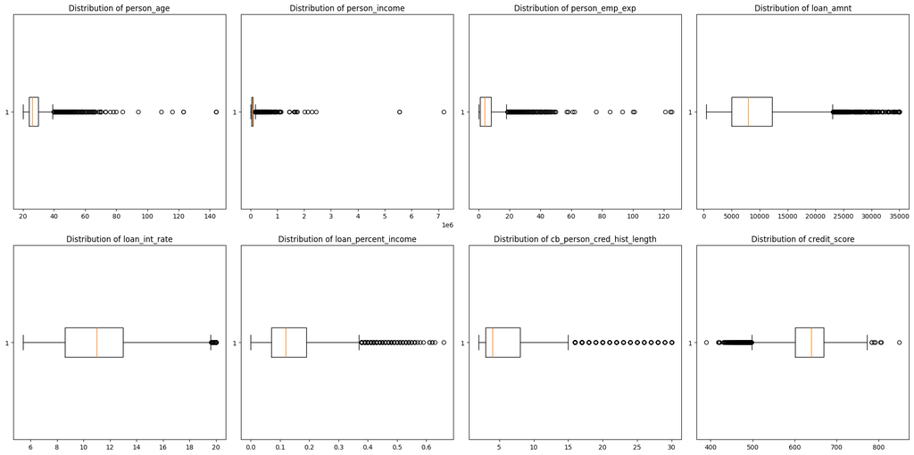

```python
numeric_columns = [col for col in df.columns if pd.api.types.is_numeric_dtype(df[col])]
numeric_columns.remove('loan_status')

n_cols = 4
n_rows = math.ceil(len(numeric_columns) / n_cols)

plt.figure(figsize=(n_cols * 5, n_rows * 5))
for i, col in enumerate(numeric_columns, 1):
    plt.subplot(n_rows, n_cols, i)
    plt.boxplot(df[col],vert=False)
    plt.title(f"Distribution of {col}")
plt.tight_layout()
plt.show()
```

# Conclusion of the previous Hypothesis:

### While the boxplots for the following columns indicate potential outliers, the following analyses apply:

> 1. **Credit Score:**  
>    Extremely low credit scores (e.g., below 400) and exceptionally high scores (e.g., above 800) might represent rare but valid data points. These values could correspond to specific groups of borrowers, such as those with poor credit histories or exceptionally strong financial profiles.
> 2. **Loan Interest Rate:**  
>    High interest rates (e.g., 20%) may be associated with high-risk borrowers. While these rates are statistical outliers, they are plausible in the context of loans for individuals with lower creditworthiness or higher lending risks.

### 3.2 KDE Plots for Numerical Columns

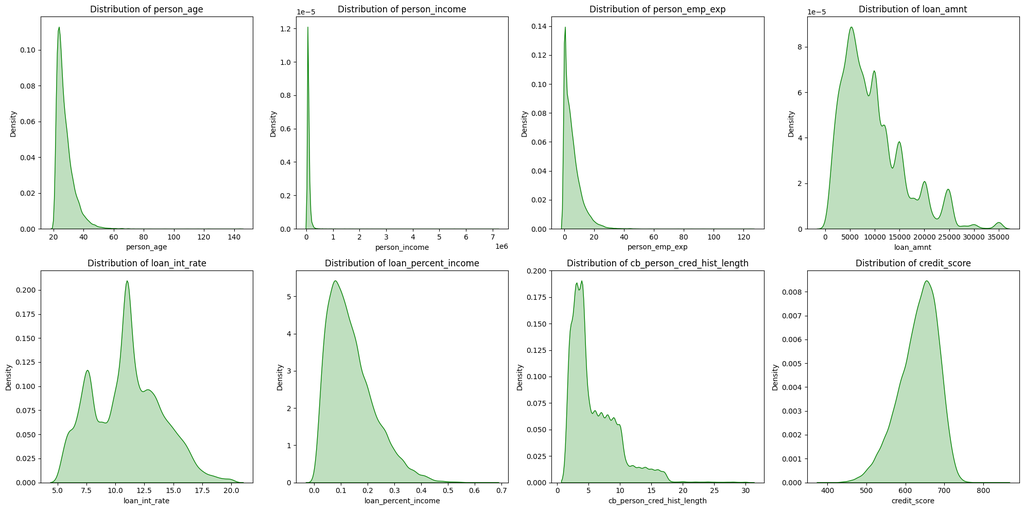

```python
n_cols = 4
n_rows = math.ceil(len(numeric_columns) / n_cols)

plt.figure(figsize=(n_cols * 5, n_rows * 5))
for i, col in enumerate(numeric_columns, 1):
    plt.subplot(n_rows, n_cols, i)
    sns.kdeplot(data=df, x=col, fill=True, color='green')
    plt.title(f"Distribution of {col}")
plt.tight_layout()
plt.show()
```

### KDE Plots Analysis for Proper Data Modeling:

> 1. **Observation:**
>    - The KDE plots show that the numeric columns, such as person_age, person_income, loan_amnt, and others, do not follow a statistical Normal (Gaussian) Distribution.
>    - Characteristics like skewness, multimodality, and heavy tails are visible in the distributions, especially in columns like person_income, loan_amnt, and person_emp_exp.
> 2. **Analysis:** **Gaussian Naive Bayes will likely perform poorly because:**
>    - It assumes that the numeric columns follow a Gaussian distribution for each class.
>    - Since this assumption is violated, the model will miscalculate probabilities
>    - Other problems may also contribute to poor performance such as poor seperation between data classes

### 3.3 Bar Plots for Categorical Columns

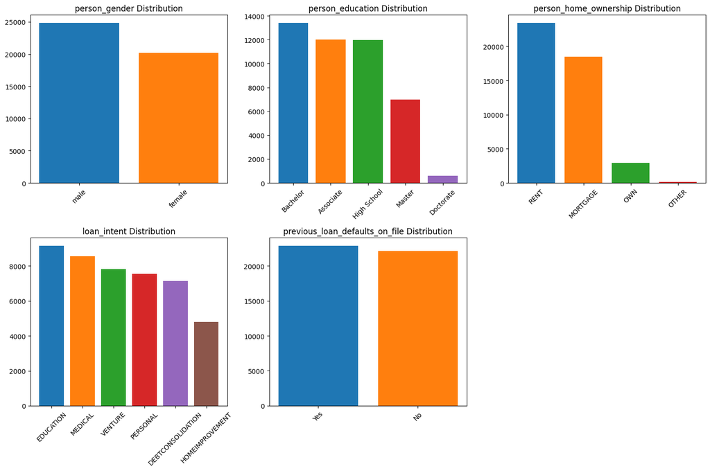

```python
categorical_columns = [col for col in df.columns if pd.api.types.is_object_dtype(df[col])]

n_cols = 3
n_rows = math.ceil(len(categorical_columns) / n_cols)

plt.figure(figsize=(n_cols * 5, n_rows * 5))

for i, col in enumerate(categorical_columns, 1):
    plt.subplot(n_rows, n_cols, i)
    value_counts = df[col].value_counts()
    colors = cm.tab10(range(len(value_counts)))
    plt.bar(value_counts.index, value_counts, color=colors)
    plt.title(f"{col} Distribution")
    plt.xticks(rotation=45)

plt.tight_layout()
plt.show()
```

### 3.4 Target Distribution Analysis

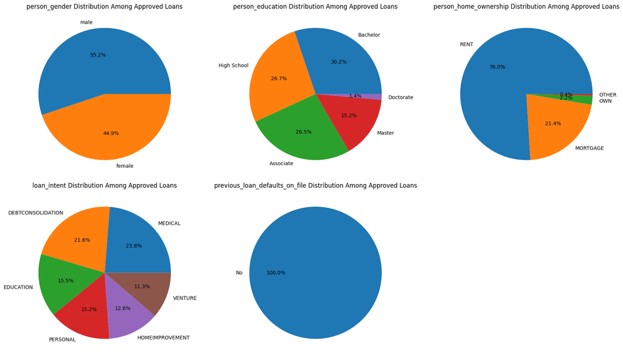

```python
approved_loans = df[df['loan_status'] == 1]
n_cols = 3
n_rows = math.ceil(len(categorical_columns) / n_cols)
plt.figure(figsize=(n_cols * 6, n_rows * 5))
for i, col in enumerate(categorical_columns, 1):
    plt.subplot(n_rows, n_cols, i)
    values = approved_loans[col].value_counts()
    plt.pie(values, labels=values.index, autopct='%1.1f%%')
    plt.title(f"{col} Distribution Among Approved Loans")
plt.tight_layout()
plt.show()
```

> Prominent Observations on Approved Loans:
> 1. Mostly people who rent houses are approved for loans
> 2. Only people who have no previous loans are approved for loans.

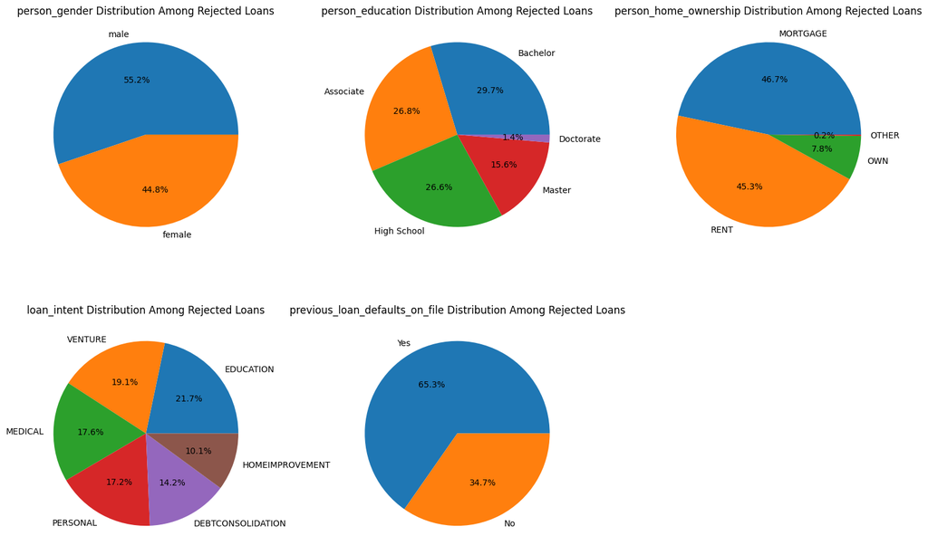

```python
rejected_loans = df[df['loan_status'] == 0]
n_cols = 3
n_rows = math.ceil(len(categorical_columns) / n_cols)
plt.figure(figsize=(n_cols * 5, n_rows * 5))
for i, col in enumerate(categorical_columns, 1):
    plt.subplot(n_rows, n_cols, i)
    values = rejected_loans[col].value_counts()
    plt.pie(values, labels=values.index, autopct='%1.1f%%')
    plt.title(f"{col} Distribution Among Rejected Loans")
plt.tight_layout()
plt.show()
```

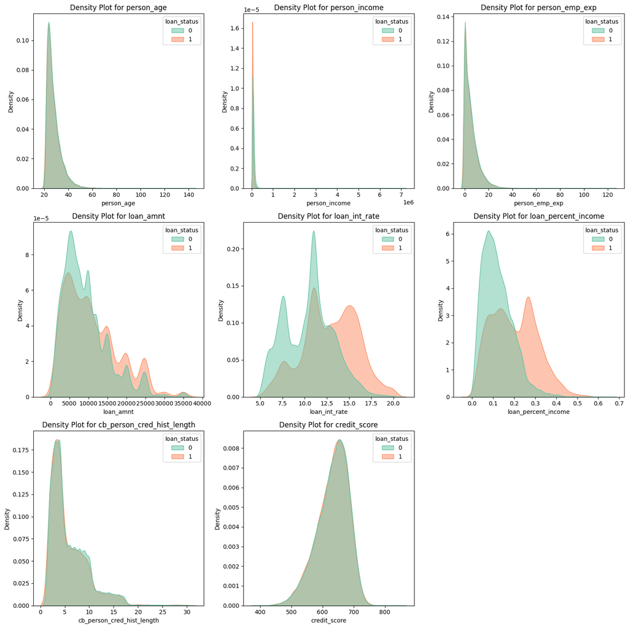

```python
n_cols = 3
n_rows = math.ceil(len(numeric_columns) / n_cols)
fig, axes = plt.subplots(n_rows, n_cols, figsize=(n_cols * 5, n_rows * 5))
axes = axes.flatten()
for i, col in enumerate(numeric_columns):
    sns.kdeplot(
        data=df, x=col, hue='loan_status', fill=True, common_norm=False,
        alpha=0.5, palette="Set2", ax=axes[i]
    )
    axes[i].set_title(f'Density Plot for {col}')
    axes[i].set_xlabel(col)
    axes[i].set_ylabel('Density')
for j in range(len(numeric_columns), len(axes)):
    fig.delaxes(axes[j])
plt.tight_layout()
plt.show()
```

### 3.5 Correlation Analysis

3.5.1 Encoding Categorical Columns

```python
encoded_df= df.copy()
encoded_df = pd.get_dummies(
    encoded_df,
    columns=['person_gender', 'previous_loan_defaults_on_file'],
    drop_first=False,
    dtype=int
)
label_encoder = LabelEncoder()
encoded_df['person_education_new'] = label_encoder.fit_transform(encoded_df['person_education'])
encoded_df['person_home_ownership_new'] = label_encoder.fit_transform(encoded_df['person_home_ownership'])
encoded_df['loan_intent_new'] = label_encoder.fit_transform(encoded_df['loan_intent'])
encoded_df.drop(columns=['person_education', 'person_home_ownership', 'loan_intent'],inplace = True)
```

3.5.2 Correlation Matrix

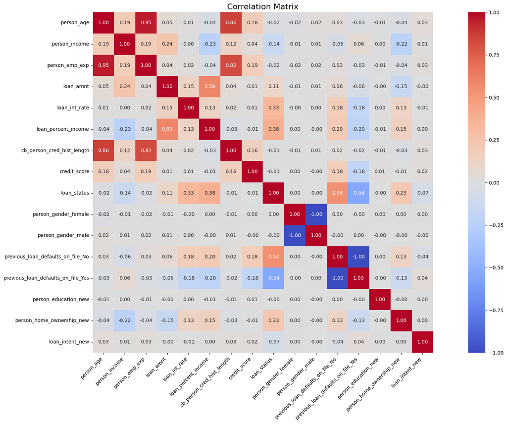

```python
correlation_matrix = encoded_df.corr()
plt.figure(figsize=(20, 12))
sns.heatmap(
    correlation_matrix,
    cmap='coolwarm',
    cbar=True,
    square=True,
    annot=True,
    annot_kws={"size": 10},
    fmt=".2f"
)
plt.xticks(rotation=45, ha='right', fontsize=10)
plt.yticks(rotation=0, fontsize=10)
plt.title('Correlation Matrix', fontsize=16)
plt.tight_layout()
plt.show()
```

3.5.3 Correlation with Target Column

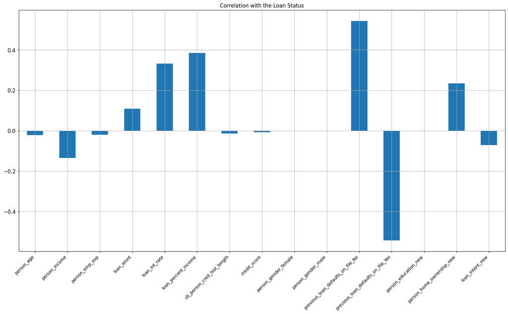

```python
encoded_df.drop('loan_status', axis=1).corrwith(encoded_df['loan_status']).plot(
    kind='bar',
    grid=True,
    figsize=(20, 10),
    title="Correlation with the Loan Status",
    fontsize=12
)
plt.xticks(rotation=45, ha='right', fontsize=10)
plt.show()
```

> Based on the all of the precedent, it can be concluded that the presence of previous loan defaults on file increases the likelihood of loan rejection.

# 4. Data Preprocessing

### 4.1 Standardization

> For this section we need to split the data into 2: categorical and numerical. Because categorical columns may affect the scaling process

```python
standardized_df = encoded_df.copy()
scaler = StandardScaler()
standardized_df[numeric_columns] = scaler.fit_transform(standardized_df[numeric_columns])
```

> After standardization, the expected standard deviation for the scaled columns (the numeric columns) should be around 1

```python
print(standardized_df[numeric_columns].std())
```

```
person_age                    1.000011
person_income                 1.000011
person_emp_exp                1.000011
loan_amnt                     1.000011
loan_int_rate                 1.000011
loan_percent_income           1.000011
cb_person_cred_hist_length    1.000011
credit_score                  1.000011
dtype: float64
```

> After standardization, the expected mean for the scaled columns (the numeric columns) should be around 0

```python
print(standardized_df[numeric_columns].mean())
```

```
person_age                   -1.191343e-16
person_income                -4.294836e-17
person_emp_exp                1.073709e-17
loan_amnt                     1.263187e-17
loan_int_rate                -2.779012e-16
loan_percent_income          -9.094947e-17
cb_person_cred_hist_length    1.957940e-17
credit_score                 -9.627065e-16
dtype: float64
```

> **We can see that the standard deviation and the mean for the numeric columns are approximately 1 and 0 respectively, the standardization process is now complete**

### 4.2 Discretization

```python
discretized_df = standardized_df.copy()
kbins = KBinsDiscretizer(n_bins=2, encode='ordinal', strategy='kmeans')
discretized_df[numeric_columns] = kbins.fit_transform(standardized_df[numeric_columns])
```

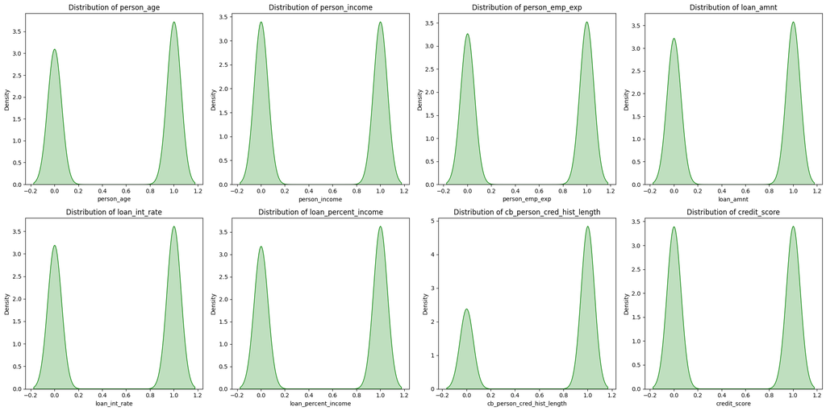

```python
numeric_columns_d = [col for col in discretized_df.columns if pd.api.types.is_numeric_dtype(discretized_df[col]) and col in numeric_columns]

n_cols = 4
n_rows = math.ceil(len(numeric_columns_d) / n_cols)

plt.figure(figsize=(n_cols * 5, n_rows * 5))
for i, col in enumerate(numeric_columns_d, 1):
    plt.subplot(n_rows, n_cols, i)
    sns.kdeplot(data=discretized_df, x=col, fill=True, color='green')
    plt.title(f"Distribution of {col}")
plt.tight_layout()
plt.show()
```

Now we will verify unique bin values for each discretized column

```python
for col in numeric_columns:
    print(f"Value counts for {col}:")
    print(discretized_df[col].value_counts())
```

```
Value counts for person_age:
person_age
1.0    24559
0.0    20441
Name: count, dtype: int64
Value counts for person_income:
person_income
1.0    22501
0.0    22499
Name: count, dtype: int64
Value counts for person_emp_exp:
person_emp_exp
1.0    23349
0.0    21651
Name: count, dtype: int64
Value counts for loan_amnt:
loan_amnt
1.0    23697
0.0    21303
Name: count, dtype: int64
Value counts for loan_int_rate:
loan_int_rate
1.0    23892
0.0    21108
Name: count, dtype: int64
Value counts for loan_percent_income:
loan_percent_income
1.0    23976
0.0    21024
Name: count, dtype: int64
Value counts for cb_person_cred_hist_length:
cb_person_cred_hist_length
1.0    30151
0.0    14849
Name: count, dtype: int64
Value counts for credit_score:
credit_score
1.0    22526
0.0    22474
Name: count, dtype: int64
```

**The discritization process is complete**

# 5. Data Modeling

We will split the encoded dataset, standardized dataset, and discretized dataset into training and testing sets for the following reasons:

1. **Decision Tree and Random Forest:** These algorithms are not sensitive to feature scaling or data distribution. Therefore, the encoded dataset (normal dataset) is suitable for their training and testing.
2. **Gaussian Naive Bayes and K-Nearest Neighbors (KNN):** These algorithms rely on distance or distribution-based calculations. Thus, the standardized dataset is used to ensure all features contribute equally and align with Gaussian Naive Bayes assumptions.
3. **Multinomial Naive Bayes:** This algorithm is designed to work with discrete, non-negative integer features. Therefore, the discretized dataset is the most appropriate for training and testing.

```python
X = encoded_df.drop(columns='loan_status')
y = encoded_df['loan_status']
X_train, X_test, y_train, y_test = train_test_split(X, y, test_size=0.3, random_state=42)

Xs = standardized_df.drop(columns='loan_status')
ys = standardized_df['loan_status']
Xs_train, Xs_test, ys_train, ys_test = train_test_split(Xs, ys, test_size=0.3, random_state=42)

Xd = discretized_df.drop(columns='loan_status')
yd = discretized_df['loan_status']
Xd_train, Xd_test, yd_train, yd_test = train_test_split(Xd, yd, test_size=0.3, random_state=42)
```

### 5.1. Decision Tree Classifier

```python
dt_param_grid = {
    'criterion': ['gini', 'entropy', 'log_loss'],
    'max_depth': [None, 5, 10, 20, 50, 100],
    'min_samples_split': [2, 5, 10, 20],
    'min_samples_leaf': [1, 2, 5, 10],
    'max_features': ['sqrt', 'log2', None],
    'class_weight': [None, 'balanced'],
    'max_leaf_nodes': [None, 10, 50, 100],
    'min_impurity_decrease': [0.0, 0.01, 0.05]
}
dt_grid_search = GridSearchCV(
    estimator=DecisionTreeClassifier(),
    param_grid=dt_param_grid,
    cv=5,
    scoring='accuracy',
    n_jobs=-1
)

dt_start_time = datetime.now()
dt_grid_search.fit(X_train, y_train)
dt_execution_time = datetime.now() - dt_start_time
```

```python
best_dt_model = dt_grid_search.best_estimator_
best_dt_params = dt_grid_search.best_params_
dt_predictions = best_dt_model.predict(X_test)

accuracy_decision = accuracy_score(y_test, dt_predictions)
precision_decision = precision_score(y_test, dt_predictions, average='weighted')
recall_decision = recall_score(y_test, dt_predictions, average='weighted')
f1_decision = f1_score(y_test, dt_predictions, average='weighted')
classification_report_dict = classification_report(y_test, dt_predictions, output_dict=True)
support_decision = classification_report_dict['weighted avg']['support']

print(f"Execution time For Decision Tree with Hyper-parameter tuning: {dt_execution_time}")
print(f"Best Parameters for Decision Tree: {dt_grid_search.best_params_}")
print("Accuracy for decision tree: ", accuracy_decision)
print("Precision for decision tree: ", precision_decision)
print("Recall for decision tree: ", recall_decision)
print("F1 Score for decision tree: ", f1_decision)
print("\nClassification Report for decision tree:")
print(classification_report(y_test, dt_predictions))
cm = confusion_matrix(y_test, dt_predictions)
print("\nConfusion Matrix for decision tree:")
print(cm)
```

```
Execution time For Decision Tree with Hyper-parameter tuning: 0:19:34.609551
Best Parameters for Decision Tree: {'class_weight': None, 'criterion': 'gini', 'max_depth': None, 'max_features': None, 'max_leaf_nodes': 100, 'min_impurity_decrease': 0.0, 'min_samples_leaf': 5, 'min_samples_split': 20}
Accuracy for decision tree:  0.9151111111111111
Precision for decision tree:  0.9130328450935694
Recall for decision tree:  0.9151111111111111
F1 Score for decision tree:  0.9132444268170713

Classification Report for decision tree:
              precision    recall  f1-score   support

           0       0.93      0.96      0.95     10493
           1       0.85      0.75      0.80      3007

    accuracy                           0.92     13500
   macro avg       0.89      0.86      0.87     13500
weighted avg       0.91      0.92      0.91     13500


Confusion Matrix for decision tree:
[[10090   403]
 [  743  2264]]
```

### 5.2. Random Forest Classifier

```python
rf_param_grid = {
    'n_estimators': [50, 100, 200, 500],
    'criterion': ['gini', 'entropy'],
    'max_depth': [None, 10, 20, 50],
    'min_samples_split': [2, 5, 10],
    'min_samples_leaf': [1, 2, 4],
    'max_features': ['sqrt', 'log2', None],
    'class_weight': [None, 'balanced'],
    'bootstrap': [True, False]
}
rf_grid_search = GridSearchCV(
    estimator=RandomForestClassifier(),
    param_grid=rf_param_grid,
    cv=5,
    scoring='accuracy',
    n_jobs=-1
)
rf_start_time = datetime.now()
rf_grid_search.fit(X_train, y_train)
rf_execution_time = datetime.now() - rf_start_time
```

```python
best_rf_model = rf_grid_search.best_estimator_
best_rf_params = rf_grid_search.best_params_
rf_predictions = best_rf_model.predict(X_test)

accuracy_randF = accuracy_score(y_test, rf_predictions)
precision_randF = precision_score(y_test, rf_predictions, average='weighted')
recall_randF = recall_score(y_test, rf_predictions, average='weighted')
f1_randF = f1_score(y_test, rf_predictions, average='weighted')
classification_report_rf = classification_report(y_test, rf_predictions, output_dict=True)
support_randF = classification_report_rf['weighted avg']['support']

print(f"Execution time For Random Forest with Hyper-parameter tuning: {rf_execution_time}")
print(f"Best Parameters for Random Forest: {rf_grid_search.best_params_}")
print("Accuracy for Random Forest: ", accuracy_randF)
print("Precision for Random Forest: ", precision_randF)
print("Recall for Random Forest: ", recall_randF)
print("F1 Score for Random Forest: ", f1_randF)
print("\nClassification Report for Random Forest:")
print(classification_report(y_test, rf_predictions))

cm_rf = confusion_matrix(y_test, rf_predictions)
print("\nConfusion Matrix for Random Forest:")
print(cm_rf)
```

```
Execution time For Random Forest with Hyper-parameter tuning: 4:58:17.298347
Best Parameters for Random Forest: {'bootstrap': True, 'class_weight': None, 'criterion': 'entropy', 'max_depth': None, 'max_features': None, 'min_samples_leaf': 1, 'min_samples_split': 2, 'n_estimators': 200}
Accuracy for Random Forest:  0.9264444444444444
Precision for Random Forest:  0.9249368555286857
Recall for Random Forest:  0.9264444444444444
F1 Score for Random Forest:  0.9250571751204921

Classification Report for Random Forest:
              precision    recall  f1-score   support

           0       0.94      0.97      0.95     10493
           1       0.87      0.79      0.83      3007

    accuracy                           0.93     13500
   macro avg       0.91      0.88      0.89     13500
weighted avg       0.92      0.93      0.93     13500


Confusion Matrix for Random Forest:
[[10144   349]
 [  644  2363]]
```

### 5.3. Gaussian Naive Bayes

```python
gauss_NB = GaussianNB()
start_time_gauss_NB = datetime.now()
gauss_NB.fit(Xs_train, ys_train)
execution_time_gauss_NB = datetime.now() - start_time_gauss_NB
gauss_NB_predictions = gauss_NB.predict(Xs_test)
accuracy_gauss_NB = accuracy_score(ys_test, gauss_NB_predictions)
precision_gauss_NB = precision_score(ys_test, gauss_NB_predictions, average='weighted')
recall_gauss_NB = recall_score(ys_test, gauss_NB_predictions, average='weighted')
f1_gauss_NB = f1_score(ys_test, gauss_NB_predictions, average='weighted')
classification_report_gauss_NB = classification_report(ys_test, gauss_NB_predictions)
print(f"Execution Time for Gaussian Naive Bayes: {execution_time_gauss_NB}")
print("Accuracy for Gaussian Naive Bayes: ", accuracy_gauss_NB)
print("Precision for Gaussian Naive Bayes: ", precision_gauss_NB)
print("Recall for Gaussian Naive Bayes: ", recall_gauss_NB)
print("F1 Score for Gaussian Naive Bayes: ", gauss_NB)
print("\nClassification Report for Gaussian Naive Bayes:")
print(classification_report_gauss_NB)

cm_naive = confusion_matrix(y_test, gauss_NB_predictions)
print("\nConfusion Matrix for Gaussian Naive Bayes:")
print(cm_naive)
```

```
Execution Time for Gaussian Naive Bayes: 0:00:00.033256
Accuracy for Gaussian Naive Bayes:  0.7315555555555555
Precision for Gaussian Naive Bayes:  0.8773386626529899
Recall for Gaussian Naive Bayes:  0.7315555555555555
F1 Score for Gaussian Naive Bayes:  GaussianNB()

Classification Report for Gaussian Naive Bayes:
              precision    recall  f1-score   support

           0       1.00      0.66      0.79     10493
           1       0.45      1.00      0.62      3007

    accuracy                           0.73     13500
   macro avg       0.73      0.83      0.71     13500
weighted avg       0.88      0.73      0.75     13500


Confusion Matrix for Gaussian Naive Bayes:
[[6877 3616]
 [   8 2999]]
```

### 5.4. Multinomial Naive Bayes

```python
multi_NB = MultinomialNB()
start_time_multi_NB = datetime.now()
multi_NB.fit(Xd_train, yd_train)
execution_time__multi_NB = datetime.now() - start_time_multi_NB
multi_NB_pred = multi_NB.predict(Xd_test)
accruacy_multi_NB = accuracy_score(yd_test, multi_NB_pred)
precision_multi_NB = precision_score(yd_test, multi_NB_pred, average='weighted')
recall_multi_NB = recall_score(yd_test, multi_NB_pred, average='weighted')
f1_multi_NB = f1_score(yd_test, multi_NB_pred, average='weighted')
classification_report__multi_NB = classification_report(yd_test, multi_NB_pred)

print(f"Execution Time for Multinomial Naive Bayes: {execution_time__multi_NB}")
print("Accuracy for Gaussian Naive Bayes: ", accruacy_multi_NB)
print("Precision for Gaussian Naive Bayes: ", precision_multi_NB)
print("Recall for Gaussian Naive Bayes: ", recall_multi_NB)
print("F1 Score for Gaussian Naive Bayes: ", f1_multi_NB)
print("\nClassification Report for Gaussian Naive Bayes:")
print(classification_report__multi_NB)

cm_naive = confusion_matrix(yd_test, multi_NB_pred)
print("\nConfusion Matrix for Gaussian Naive Bayes:")
print(cm_naive)
```

```
Execution Time for Multinomial Naive Bayes: 0:00:00.009292
Accuracy for Gaussian Naive Bayes:  0.8508148148148148
Precision for Gaussian Naive Bayes:  0.8478904987826191
Recall for Gaussian Naive Bayes:  0.8508148148148148
F1 Score for Gaussian Naive Bayes:  0.8491670768051851

Classification Report for Gaussian Naive Bayes:
              precision    recall  f1-score   support

           0       0.90      0.91      0.90     10493
           1       0.68      0.64      0.65      3007

    accuracy                           0.85     13500
   macro avg       0.79      0.77      0.78     13500
weighted avg       0.85      0.85      0.85     13500


Confusion Matrix for Gaussian Naive Bayes:
[[9575  918]
 [1096 1911]]
```

5.5. KNearest Neighbors Classifier (KNN)

**We first find the best number of neighbors**

```python
param_grid_knn = {
    'n_neighbors': [3, 5, 10, 15, 20, 23, 30],
    'weights': ['uniform', 'distance'],
    'metric': ['euclidean', 'manhattan', 'minkowski', 'chebyshev'],
    'p': [1, 2, 3],
    'algorithm': ['auto', 'ball_tree', 'kd_tree', 'brute'],
    'leaf_size': [10, 20, 30, 50],
}

knn_grid_search = GridSearchCV(
    estimator=KNeighborsClassifier(),
    param_grid=param_grid_knn,
    cv=5,
    scoring='accuracy',
    n_jobs=-1,
    verbose=2
)
start_time_knn_tuning = datetime.now()
knn_grid_search.fit(Xs_train, ys_train)
execution_time_knn_tuning = datetime.now() - start_time_knn_tuning
```

```
Fitting 5 folds for each of 2688 candidates, totalling 13440 fits
```

```python
best_knn_model = knn_grid_search.best_estimator_
best_knn_params = knn_grid_search.best_params_
knn_pred = best_knn_model.predict(Xs_test)

accuracy_knn = accuracy_score(ys_test, knn_pred)
precision_knn = precision_score(ys_test, knn_pred, average='weighted')
recall_knn = recall_score(ys_test, knn_pred, average='weighted')
f1_knn = f1_score(ys_test, knn_pred, average='weighted')
classification_report_knn = classification_report(ys_test, knn_pred)

print(f"Execution Time for KNN Hyperparameter Tuning: {execution_time_knn_tuning}")
print("Best Parameters for KNN:", best_knn_params)
print("Accuracy for KNN: ", accuracy_knn)
print("Precision for KNN: ", precision_knn)
print("Recall for KNN: ", recall_knn)
print("F1 Score for KNN: ", f1_knn)
print("\nClassification Report for KNN:")
print(classification_report_knn)

cm_knn = confusion_matrix(ys_test, knn_pred)
print("\nConfusion Matrix for KNN:")
print(cm_knn)
```

```
Execution Time for KNN Hyperparameter Tuning: 3:17:49.683750
Best Parameters for KNN: {'algorithm': 'auto', 'leaf_size': 10, 'metric': 'manhattan', 'n_neighbors': 20, 'p': 1, 'weights': 'distance'}
Accuracy for KNN:  0.9005925925925926
Precision for KNN:  0.8974758632675205
Recall for KNN:  0.9005925925925926
F1 Score for KNN:  0.8972573362619889

Classification Report for KNN:
              precision    recall  f1-score   support

           0       0.92      0.96      0.94     10493
           1       0.83      0.69      0.76      3007

    accuracy                           0.90     13500
   macro avg       0.87      0.83      0.85     13500
weighted avg       0.90      0.90      0.90     13500


Confusion Matrix for KNN:
[[10071   422]
 [  920  2087]]
```

```python
best_params = [best_dt_params,best_rf_params,best_knn_params]
execution_times = [dt_execution_time,rf_execution_time,execution_time_gauss_NB,execution_time__multi_NB,execution_time_knn_tuning]
accuracies = [accuracy_decision,accuracy_randF,accuracy_gauss_NB,accruacy_multi_NB,accuracy_knn]
precisions = [precision_decision,precision_randF,precision_gauss_NB,precision_multi_NB,precision_knn]
f1_scores = [f1_decision,f1_randF,f1_gauss_NB,f1_multi_NB,f1_knn]
recall_scores = [recall_decision,recall_randF,recall_gauss_NB,recall_multi_NB,recall_knn]

"""
The following data will be saved as they are obtained through the training phase.
This is particularly important since algorithms like Random Forest and KNN required
significant computational time, taking over 3 hours to train during
hyperparameter tuning.
"""
training_data = {'best_params':best_dt_params,'execution_times':execution_times}
with open('trainig_data','wb') as f:
    pickle.dump(training_data,f)
```

```python
with open('Decision_Tree_Loan_Prediction','wb') as f:
    pickle.dump(best_dt_model,f)
```

```python
import pickle
with open('Random_Forest_Loan_Prediction','wb') as f:
    pickle.dump(best_rf_model,f)
```

```python
import pickle
with open('Gaussian_Naive_Bayes_Loan_Prediction','wb') as f:
    pickle.dump(gauss_NB,f)
```

```python
import pickle
with open('Multinomial_Naive_Bayes_Loan_Prediction','wb') as f:
    pickle.dump(multi_NB,f)
```

```python
import pickle
with open('KNearest_Neighbors_Loan_Prediction','wb') as f:
    pickle.dump(best_knn_model,f)
```

# 6. Models Evaluation

### 6.1 Model Comparison Based on Accuracy

```python
models = ['Decision Tree', 'Random Forest', 'Guassian NB','Multinomial NB', 'KNN']
colors = cm.tab10(range(len(models)))
```

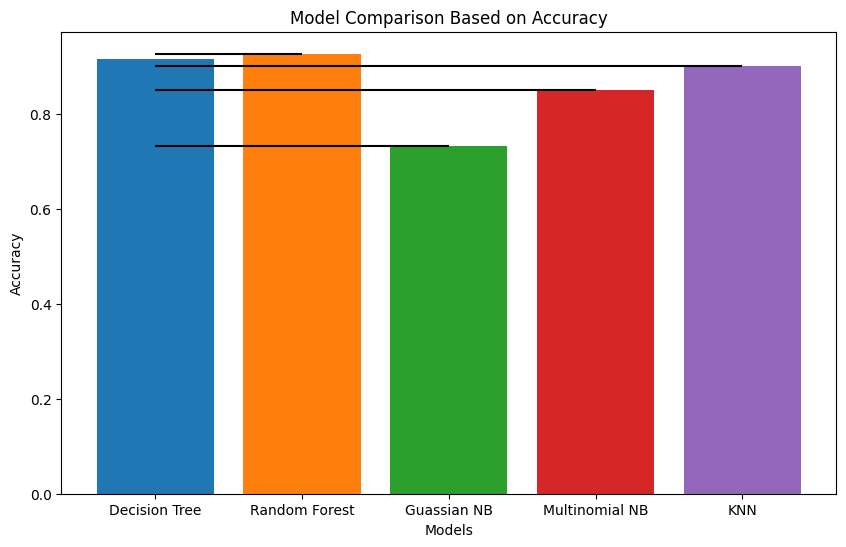

```python
plt.figure(figsize=(10, 6))
plt.bar(models, accuracies, color=colors)
for i in range(len(accuracies)):
    plt.hlines(accuracies[i],0,models[i],"black")
plt.xlabel('Models')
plt.ylabel('Accuracy')
plt.title('Model Comparison Based on Accuracy')
plt.show()
```

### 6.2 Model Comparison Based on Precision

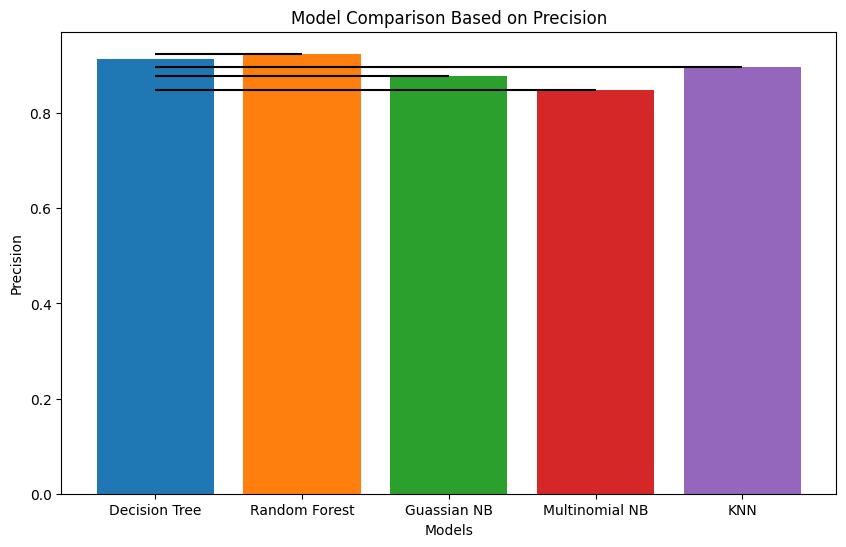

```python
plt.figure(figsize=(10, 6))
plt.bar(models, precisions, color=colors)
for i in range(len(precisions)):
    plt.hlines(precisions[i],0,models[i],"black")
plt.xlabel('Models')
plt.ylabel('Precision')
plt.title('Model Comparison Based on Precision')
plt.show()
```

### 6.3 Model Comparison Based on Recall

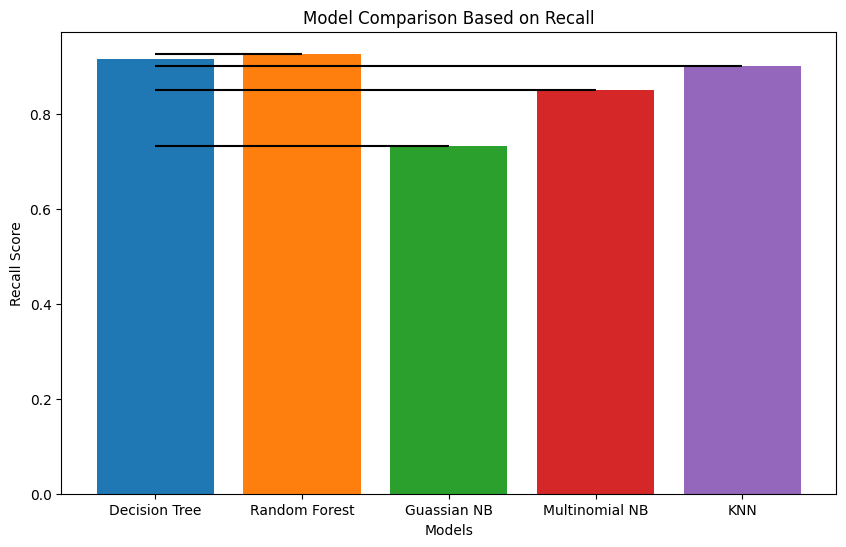

```python
plt.figure(figsize=(10, 6))
plt.bar(models, recall_scores, color=colors)
for i in range(len(recall_scores)):
    plt.hlines(recall_scores[i],0,models[i],"black")
plt.xlabel('Models')
plt.ylabel('Recall Score')
plt.title('Model Comparison Based on Recall')
plt.show()
```

### 6.4 Model Comparison Based on F1 Score

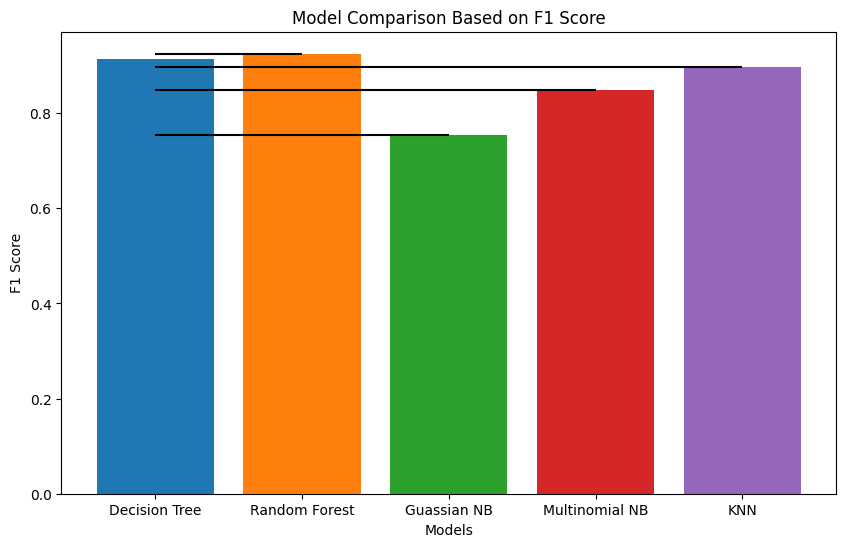

```python
plt.figure(figsize=(10, 6))
plt.bar(models, f1_scores, color=colors)
for i in range(len(f1_scores)):
    plt.hlines(f1_scores[i],0,models[i],"black")
plt.xlabel('Models')
plt.ylabel('F1 Score')
plt.title('Model Comparison Based on F1 Score')
plt.show()
```

### 6.5 Table of Metrics

```python
Model_Metrics = {
    'Model': models,
    'Accuracy':accuracies,
    'Precision':precisions,
    'Recall':recall_scores,
    'F1 Score':f1_scores,
}

comparison = pd.DataFrame(Model_Metrics)
comparison
```

|  | Model | Accuracy | Precision | Recall | F1 Score |
| --- | --- | --- | --- | --- | --- |
| 0 | Decision Tree | 0.915111 | 0.913033 | 0.915111 | 0.913244 |
| 1 | Random Forest | 0.926444 | 0.924937 | 0.926444 | 0.925057 |
| 2 | Guassian NB | 0.731556 | 0.877339 | 0.731556 | 0.754018 |
| 3 | Multinomial NB | 0.850815 | 0.847890 | 0.850815 | 0.849167 |
| 4 | KNN | 0.900593 | 0.897476 | 0.900593 | 0.897257 |

# 7. Conclusion

- Random Forest is the best-performing model for loan prediction due to its ability to maintain high accuracy, precision, and recall, which are essential for reducing both false approvals and false denials.
- Gaussian Naive Bayes performed the worst because as expected, due to the non-Gaussian distributions in the provided dataseet.
- Having previous defaulted loans on file guarantees loan rejection, as 100% of approved loans were granted to individuals with no history of defaulted loans.
- While having no previous defaulted loans on file significantly increases the chances of loan approval, it does not guarantee approval, as 34.7% of rejected loans were granted to individuals with no previous defaults.